# B110 - TiVo Segmentation Exercise

```python
import numpy as np
import pandas as pd
import matplotlib.pyplot as plt
import seaborn as sns
sns.set()
```

```python
data = pd.read_csv('Data.csv')
data.head()
```

|  | ID | Gender | Marital Status | Work Status | Education | Annual Income (x1000 $) | Age | Location | Purchasing Decision-maker | Purchasing Location | Monthly Electronics Spend | Monthly Household Spend | Purchasing Frequency (every x months) | Technology Adoption | TV Viewing (hours/day) | Favorite feature |
| --- | --- | --- | --- | --- | --- | --- | --- | --- | --- | --- | --- | --- | --- | --- | --- | --- |
| 0 | 1 | male | married | professional | none | 49 | 30 | Florida | family | mass-consumer electronics | 35 | 150 | 13 | late | 2 | saving favorite shows to watch as a family |
| 1 | 2 | male | single | none | none | 46 | 36 | Alabama | single | mass-consumer electronics | 35 | 163 | 26 | late | 10 | saving favorite shows to watch as a family |
| 2 | 3 | male | married | professional | BA | 58 | 66 | Massachusetts | family | specialty stores | 64 | 103 | 13 | early | 0 | time shifting |
| 3 | 4 | male | married | none | PhD | 51 | 78 | New York | family | mass-consumer electronics | 33 | 154 | 22 | late | 5 | saving favorite shows to watch as a family |
| 4 | 5 | female | single | none | none | 46 | 52 | Montana | single | mass-consumer electronics | 45 | 161 | 47 | late | 2 | saving favorite shows to watch as a family |

## Data Cleaning

```python
data.info()
```

```
<class 'pandas.core.frame.DataFrame'>
RangeIndex: 1000 entries, 0 to 999
Data columns (total 16 columns):
 #   Column                                 Non-Null Count  Dtype
---  ------                                 --------------  -----
 0   ID                                     1000 non-null   int64
 1   Gender                                 1000 non-null   object
 2   Marital Status                         1000 non-null   object
 3   Work Status                            1000 non-null   object
 4   Education                              1000 non-null   object
 5   Annual Income (x1000 $)                1000 non-null   int64
 6   Age                                    1000 non-null   int64
 7   Location                               1000 non-null   object
 8   Purchasing Decision-maker              1000 non-null   object
 9   Purchasing Location                    1000 non-null   object
 10  Monthly Electronics Spend              1000 non-null   int64
 11  Monthly Household Spend                1000 non-null   int64
 12  Purchasing Frequency (every x months)  1000 non-null   int64
 13  Technology Adoption                    1000 non-null   object
 14  TV Viewing (hours/day)                 1000 non-null   int64
 15  Favorite feature                       1000 non-null   object
dtypes: int64(7), object(9)
memory usage: 125.1+ KB
```

### Problems Identified

- Change annual income & age to numeric value
- Categorical data needs to be either factorized for the regression analysis.
- ID column is not useful

```python
pd.to_numeric(data['Annual Income (x1000 $)'])
pd.to_numeric(data['Age'])
data.drop(columns=['ID'], inplace=True)

data.info()
```

```
<class 'pandas.core.frame.DataFrame'>
RangeIndex: 1000 entries, 0 to 999
Data columns (total 15 columns):
 #   Column                                 Non-Null Count  Dtype
---  ------                                 --------------  -----
 0   Gender                                 1000 non-null   object
 1   Marital Status                         1000 non-null   object
 2   Work Status                            1000 non-null   object
 3   Education                              1000 non-null   object
 4   Annual Income (x1000 $)                1000 non-null   int64
 5   Age                                    1000 non-null   int64
 6   Location                               1000 non-null   object
 7   Purchasing Decision-maker              1000 non-null   object
 8   Purchasing Location                    1000 non-null   object
 9   Monthly Electronics Spend              1000 non-null   int64
 10  Monthly Household Spend                1000 non-null   int64
 11  Purchasing Frequency (every x months)  1000 non-null   int64
 12  Technology Adoption                    1000 non-null   object
 13  TV Viewing (hours/day)                 1000 non-null   int64
 14  Favorite feature                       1000 non-null   object
dtypes: int64(6), object(9)
memory usage: 117.3+ KB
```

### Removing the Outliers from Annual Income

```python
data[data['Annual Income (x1000 $)'] > 100]

print(f"Length of dataset before dropping outliers: {len(data)}")
data = data.drop(data[data['Annual Income (x1000 $)'] > 100].index)
print(f"Length of dataset after dropping outliers: {len(data)}")
```

[output not shown]

## Question 1

In the Survey Data worksheet, insert one row above the column labels and categorize each data field by its segmentation parameter type: “Demographic,” “Purchasing,” “Behavioral,” “Attitude,” or “Other.”

```python
cols = data.columns
segment_type = ['Demographic','Purchasing','Behavioral','Attitude','Other']

segmentation_dct = pd.DataFrame({
    cols[0]: segment_type[0], # gender
    cols[1]: segment_type[0], # marital status
    cols[2]: segment_type[0], # work status
    cols[3]: segment_type[0], # education
    cols[4]: segment_type[0], # annual income
    cols[5]: segment_type[0], # age
    cols[6]: segment_type[0], # location
    cols[7]: segment_type[1], # purchasing decision-maker
    cols[8]: segment_type[1], # purchasing location,
    cols[9]: segment_type[2], # monthly electronics spend
    cols[10]: segment_type[2], # monthly household spend
    cols[11]: segment_type[1], # purchasing frequency (every x months)
    cols[12]: segment_type[3], # tech adoption
    cols[13]: segment_type[2], # TV viewing
    cols[14]: segment_type[4], # fav feature
}, index=['Segment Type'])

segmentation_dct.T.sort_values(by=['Segment Type'])
```

|  | Segment Type |
| --- | --- |
| Technology Adoption | Attitude |
| Monthly Electronics Spend | Behavioral |
| Monthly Household Spend | Behavioral |
| TV Viewing (hours/day) | Behavioral |
| Gender | Demographic |
| Marital Status | Demographic |
| Work Status | Demographic |
| Education | Demographic |
| Annual Income (x1000 $) | Demographic |
| Age | Demographic |
| Location | Demographic |
| Favorite feature | Other |
| Purchasing Decision-maker | Purchasing |
| Purchasing Location | Purchasing |
| Purchasing Frequency (every x months) | Purchasing |

## Question 2

In the Survey Data worksheet, do the following:

a. Insert a column labeled “Annual spending on electronics” that calculates the average annual spending on electronics.

b. Insert another column labeled “Spending as % of income” that calculates annual spending on electronics as a percentage of annual income.

```python
data['Yearly Electronics Expenditure'] = data['Monthly Electronics Spend'] * 12
data['Electronics Spending to Income Ratio'] = data['Yearly Electronics Expenditure'] / (data['Annual Income (x1000 $)'] * 1000)

data[['Yearly Electronics Expenditure', 'Electronics Spending to Income Ratio']].head(10)
```

|  | Yearly Electronics Expenditure | Electronics Spending to Income Ratio |
| --- | --- | --- |
| 0 | 420 | 0.008571 |
| 1 | 420 | 0.009130 |
| 2 | 768 | 0.013241 |
| 3 | 396 | 0.007765 |
| 4 | 540 | 0.011739 |
| 5 | 168 | 0.005419 |
| 6 | 216 | 0.006545 |
| 7 | 276 | 0.009517 |
| 8 | 888 | 0.015579 |
| 9 | 192 | 0.006400 |

## Question 3

Create a table for each attribute (e.g., education) and record the percentage of responses for each answer (e.g., % of respondents answering “none,” % with “BA,” % with “MA,” % with “PhD”).

```python
category_stats = data.describe(exclude=[np.number])
category_stats
```

[output not shown]

```python
def add_value_labels(ax, spacing=5, color='white', size='20'):
    for rect in ax.patches:
        y_value = rect.get_height()
        x_value = rect.get_x() + rect.get_width() / 2
        space = spacing
        space *= -1
        va = 'top'
        label = "{:.2f}".format(y_value)
        ax.annotate(label, (x_value, y_value), xytext=(0, space), textcoords="offset points", ha='center', va=va, color=color, size=size)

def plot_percentages(col_name, x_rotation=90, annot=True):
    response_percentage = data[col_name].value_counts(normalize=True)
    plt.title(col_name, size=20)
    ax = response_percentage.plot(kind='bar')
    if annot:
        add_value_labels(ax, spacing=20)
    plt.xticks(rotation=x_rotation, size=13)
    plt.yticks(size=13)
    return response_percentage
```

### Calculating the Percentages

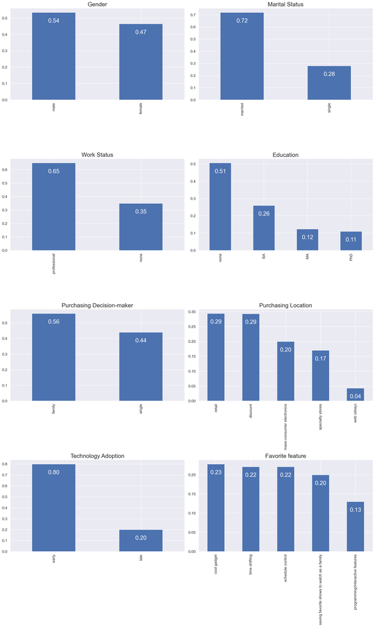

```python
first_batch = category_stats.drop(columns=['Location'])

plt.figure(figsize=(18, 30), dpi=150)
for i in range(len(first_batch.columns)):
    plt.subplot(4,2,i+1)
    plot_percentages(first_batch.columns[i])
plt.tight_layout()
```

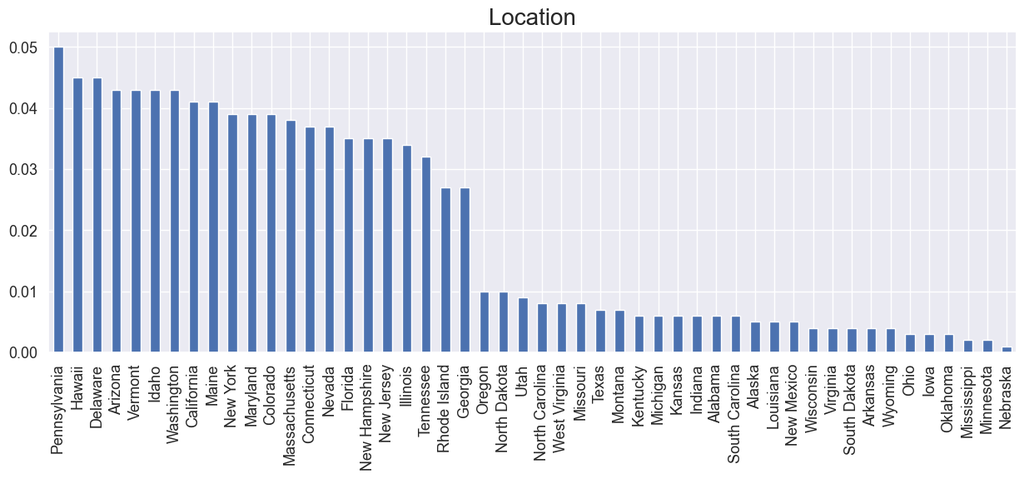

```python
plt.figure(figsize=(15,5), dpi=100)
loc_data = plot_percentages('Location', x_rotation=90, annot=False)
```

## Question 4

#### Question A

How many married men who are early adopters have monthly electronics spend high enough that they can afford to purchase a TiVo for $499 and still be able to spend more on electronics in the next two years?

```python
filtered_data = data[(data['Gender'] == 'male')
                     & (data['Marital Status'] == 'married')
                     & (data['Technology Adoption'] == 'early')
                     & (data['Annual spending on electronics'] * 3 > 499)]

print(f"Count of married men who are early technology adopters and spend over $499 on electronics in three years: {len(filtered_data)}")
```

```
Count of married men who are early technology adopters and spend over $499 on electronics in three years: 285
```

b. How many women with an education level of MA or PhD are making purchasing decisions for electronics without discussing them with a spouse, either because they are single or because they are making purchasing decisions without the involvement of their spouses?

```python
filtered_data = data[(data['Gender'] == 'female')
                     & (data['Education'].isin(['MA', 'PhD']))
                     & (data['Purchasing Decision-maker'] == 'single')]
single_status = filtered_data[filtered_data['Marital Status'] == 'single']

print(f"Number of single females with MA/PhD making their own purchasing decisions: {len(filtered_data)}")
print(f"Count of single: {len(single_status)}")
print(f"Count of not single: {len(filtered_data) - len(single_status)}")
```

```
Number of single females with MA/PhD making their own purchasing decisions: 55
Count of single: 48
Count of not single: 7
```

c. How many early adopters purchase electronics at least once every year, and do so in stores that specialize in electronics?

```python
filtered_data = data[(data['Technology Adoption'] == 'early')
                     & (data['Purchasing Frequency (every x months)'] <= 12)
                     & (data['Purchasing Location'] == 'specialty stores')]

print(f"Number of early adopters who buy electronics every 12 months or less, exclusively from specialty stores: {len(filtered_data)}")
```

```
Number of early adopters who buy electronics every 12 months or less, exclusively from specialty stores: 131
```

d. How many seniors (over the age of 65) spend more than six hours a day watching TV? What is their income range? What is their average annual income?

```
Number of individuals older than 65 watching more than 6 hours of TV daily: 20
Range of annual income in thousands: (41, 55)
Mean annual income in thousands: 48.6
```

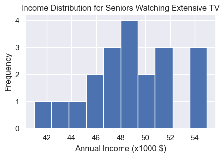

```python
filtered_data = data[(data['Age'] > 65) & (data['TV Viewing (hours/day)'] > 6)]

print(f"Number of individuals older than 65 watching more than 6 hours of TV daily: {len(filtered_data)}")
print(f"Range of annual income in thousands: ({filtered_data['Annual Income (x1000 $)'].min()}, {filtered_data['Annual Income (x1000 $)'].max()})")
print(f"Mean annual income in thousands: {filtered_data['Annual Income (x1000 $)'].mean()}")

plt.figure(figsize=(5, 3), dpi=100)
plt.hist(filtered_data['Annual Income (x1000 $)'])
plt.title("Income Distribution for Seniors Watching Extensive TV")
plt.xlabel('Annual Income (x1000 $)')
plt.ylabel('Frequency')
```

## Question 5

Correlate Annual Income with Age and record the answer in the Question 5 worksheet. What is the correlation (r2)? Both the CORREL function and the Analysis Toolpak add-in in Excel return r, which will need to be squared. You may also use any other method to calculate the correlation (r2).

If you are unsure how correlation is calculated, the following simple definition is provided. More detail is online at: http://onlinestatbook.com/2/describing_bivariate_data/calculation.html.

When you are calculating the correlation of attributes X and Y, calculate the mean of each attribute and subtract it from each value of X and Y, respectively. This will result in x and y, known as deviation scores. The calculation of r is shown in the following formula:

$r = \frac{\sum xy}{\sqrt{\sum x^2 \sum y^2}}$

```python
income_age_corr = data[['Annual Income (x1000 $)','Age']].corr(method='pearson')**2
income_age_corr.round(2)
```

|  | Annual Income (x1000 $) | Age |
| --- | --- | --- |
| Annual Income (x1000 $) | 1.00 | 0.03 |
| Age | 0.03 | 1.00 |

## Question 6

Record your answers to the following questions in the Question 6 worksheet:

#### Question A

Code Gender as a number. What is the correlation (r2) between it and Annual Income?

```python
# factorize gender as number
coded_gender, gender_map = pd.factorize(data['Gender'])


income_gender = pd.DataFrame({'Annual income': data['Annual Income (x1000 $)'],
                              'Gender': coded_gender})

income_gender_corr = income_gender[['Annual income','Gender']].corr(method='pearson')**2
income_gender_corr.round(4)
```

|  | Annual income | Gender |
| --- | --- | --- |
| Annual income | 1.0000 | 0.0066 |
| Gender | 0.0066 | 1.0000 |

#### Question B

Explain why it makes no difference which numbers are used to code Gender or other non-numeric attributes.

The particular choice of numbers does not matter in this context because these numbers are simply placeholders that represent different categories.

The key point is that these coded numbers do not have any inherent numerical meaning and do not imply any sort of mathematical relationship between the categories. They are nominal values, meaning they are used for labeling purposes only and do not have a meaningful order or scale.

Here are a few reasons why the specific numbers used to code non-numeric attributes make no difference:

1. Interpretability: The main purpose of coding is to convert categories into a format that can be easily processed by statistical software or machine learning algorithms. As long as the mapping between the original categories and the coded numbers is consistent and well-understood, it does not matter what numbers are used.
2. No Mathematical Operations: Since the numbers are placeholders for categories, you do not perform mathematical operations on them like you would with ordinal or continuous numerical data. This means that the actual values of the numbers do not impact the results of any analysis.
3. Flexibility in Analysis: When analyzing categorical data, statistical methods or machine learning algorithms treat these numbers as representing distinct categories, regardless of their actual values. This means that whether you code male as 1 and female as 0, or male as 0 and female as 1, or use any other numeric coding, the results of your analysis should remain the same.

## Question 7

Repeat the correlation analysis for the following four pairs of attributes and record their correlation (r2) in the Question 7 worksheet.

a. Age and Purchasing Frequency

b. Annual Income and TV Viewing

c. Education and Favorite Feature

d. Monthly Electronics Spend and Monthly Household Spend

Of the four correlations, are any high enough to make one of the attributes redundant? In other words, can you describe any of the attributes simply by saying that “it behaves like attribute X?”

### Correlation Heatmap

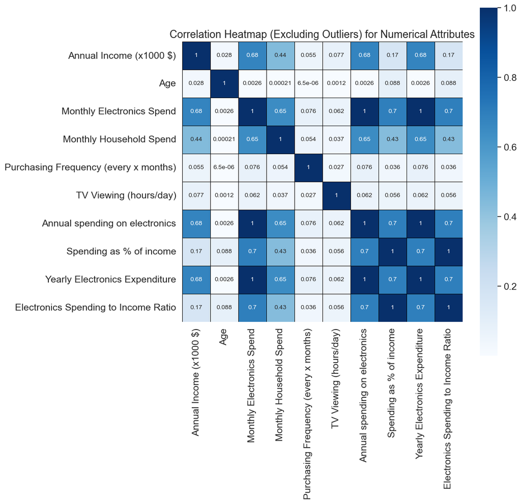

```python
import seaborn as sns
import matplotlib.pyplot as plt

# Calculating the squared Pearson correlation matrix
correlation_matrix = data.corr('pearson') ** 2

# Creating the figure for the heatmap
plt.figure(figsize=(10, 10), dpi=100)

# Setting the title of the heatmap
plt.title("Correlation Heatmap (Excluding Outliers) for Numerical Attributes")

# Adjusting the font scale for better readability
sns.set(font_scale=1.4)

# Creating the heatmap
sns.heatmap(correlation_matrix,
            annot=True,             # Annotate each cell with the numeric value
            annot_kws={'size': 10}, # Adjusting the font size of the annotation
            square=True,            # Make cells square
            cmap='Blues',           # Using a blue color map
            linewidths=.5,          # Setting the width of the lines between cells
            linecolor='black',      # Setting the color of the lines between cells
            cbar=True)              # Displaying the color bar

# Rotating the y-axis labels for better readability
plt.yticks(rotation=0)

# Showing the plot
plt.show()
```

The correlation coefficients for the pairings of numerical attributes can be found in the correlation heatmaps above:

b. The monthly expenditure on electronics and household expenses is 0.65.

### Correlation Analysis of Education and Favorite Feature

Education and favorite feature are both categorical variables, so before figuring out their correlation coefficients, they must be converted to numerical values.

Factorization is used to transform education; values such as "none," "BA," "MA," and "PhD" are encoded as [0,1,2,3], in that order. We make the assumption that values range from 0 to PhD.

One-hot encoding is used to transform the variable because there is no hierarchy for favorite features.

The coefficient values between various educational levels and a customer's preferred feature are displayed in the correlation heatmap. Most remarkably, "saving favorite TV shows to watch as a family" is positively correlated with education level by 0.32. Education and favorite feature are both categorical variables, so before figuring out their correlation coefficients, they must be converted to numerical values.

```
(array([0.5]), [Text(0, 0.5, 'Education Level')])
```

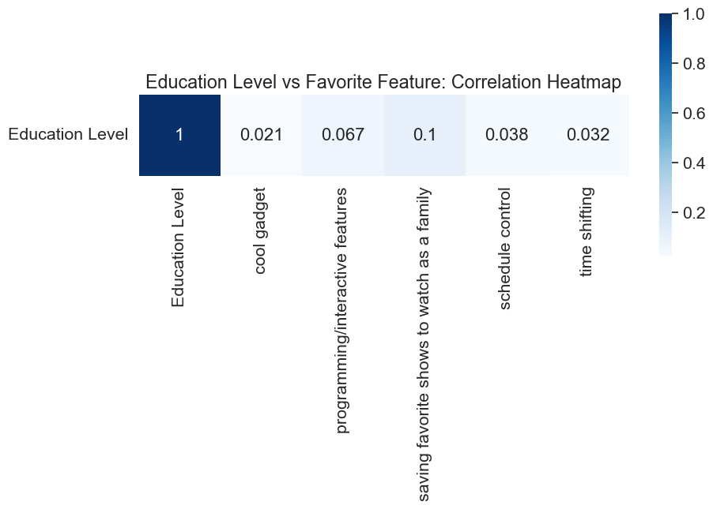

```python
encoded_education = pd.DataFrame({
    'Education Level': data['Education'].astype(
        pd.CategoricalDtype(categories=['none', 'BA', 'MA', 'PhD'])
    ).cat.codes
})

favorite_feature_dummies = pd.get_dummies(data['Favorite feature'])
education_favorite_feature = encoded_education.join(favorite_feature_dummies)

plt.figure(figsize=(10, 4))
plt.title("Education Level vs Favorite Feature: Correlation Heatmap")
sns.set(font_scale=1.4)
sns.heatmap(education_favorite_feature.corr().iloc[[0]] ** 2,
            annot=True,
            annot_kws={'size': 16},
            square=True,
           cmap='Blues')
plt.yticks(rotation=0)
```

## Question 8

Select one or more attributes to use as the basis for generating two segmentation schemes. For example, you could choose Age as the basis for creating segments based on age ranges. Or you could select two attributes that would help you segment by willingness to buy versus ability to pay.

As you generate segmentation schemes, Use the data in the ""Survey Data"" worksheet to fill each cell in the tables shown below. Remember to try to create segments that are homogenous internally and heterogeneous across segments for the indicated number of segments. Not all attributes will be used.

### Selecting Segmentation Characteristics

Since age, marital status, and education were unrelated to anything outside of the individual, Cerf (2016) proposed segmenting the population based on these factors.

#### Binary category data:

Gender, Technology Adoption, Marital Status, Work Status, and Purchasing Decision-Maker.

```python
gender_encoded, gender_categories = pd.factorize(data['Gender'])
marital_status_encoded, marital_status_categories = pd.factorize(data['Marital Status'])
work_status_encoded, work_status_categories = pd.factorize(data['Work Status'])
decision_maker_encoded, decision_maker_categories = pd.factorize(data['Purchasing Decision-maker'])
tech_adoption_encoded, tech_adoption_categories = pd.factorize(data['Technology Adoption'])
education_encoded, education_categories = pd.factorize(data['Education'])

print("The following categories have been mapped to 0, 1:")
print(gender_categories)
print(marital_status_categories)
print(work_status_categories)
print(decision_maker_categories)
print(tech_adoption_categories)

print("\nThe following category has been mapped to 0, 1, 2, 3:")
print(education_categories)

data_transformed = data.copy(deep=True)
data_transformed.drop(columns=['Gender', 'Marital Status', 'Work Status', 'Purchasing Decision-maker', 'Technology Adoption', 'Education', 'Purchasing Location', 'Favorite feature', 'Location'], inplace=True)
data_transformed['Gender'] = gender_encoded
data_transformed['Marital Status'] = marital_status_encoded
data_transformed['Work Status'] = work_status_encoded
data_transformed['Purchasing Decision-maker'] = decision_maker_encoded
data_transformed['Technology Adoption'] = tech_adoption_encoded
data_transformed['Education'] = education_encoded
```

```
The following categories have been mapped to 0, 1:
Index(['male', 'female'], dtype='object')
Index(['married', 'single'], dtype='object')
Index(['professional', 'none'], dtype='object')
Index(['family', 'single'], dtype='object')
Index(['late', 'early'], dtype='object')

The following category has been mapped to 0, 1, 2, 3:
Index(['none', 'BA', 'PhD', 'MA'], dtype='object')
```

```python
data_all.head()
```

|  | Annual Income (x1000 $) | Age | Monthly Electronics Spend | Monthly Household Spend | Purchasing Frequency (every x months) | TV Viewing (hours/day) | Annual spending on electronics | Spending as % of income | Yearly Electronics Expenditure | Electronics Spending to Income Ratio | Gender | Marital Status | Work Status | Purchasing Decision-maker | Technology Adoption | Education |
| --- | --- | --- | --- | --- | --- | --- | --- | --- | --- | --- | --- | --- | --- | --- | --- | --- |
| 0 | 49 | 30 | 35 | 150 | 13 | 2 | 420 | 0.008571 | 420 | 0.008571 | 0 | 0 | 0 | 0 | 0 | 0 |
| 1 | 46 | 36 | 35 | 163 | 26 | 10 | 420 | 0.009130 | 420 | 0.009130 | 0 | 1 | 1 | 1 | 0 | 0 |
| 2 | 58 | 66 | 64 | 103 | 13 | 0 | 768 | 0.013241 | 768 | 0.013241 | 0 | 0 | 0 | 0 | 1 | 1 |
| 3 | 51 | 78 | 33 | 154 | 22 | 5 | 396 | 0.007765 | 396 | 0.007765 | 0 | 0 | 1 | 0 | 0 | 2 |
| 4 | 46 | 52 | 45 | 161 | 47 | 2 | 540 | 0.011739 | 540 | 0.011739 | 1 | 1 | 1 | 1 | 0 | 0 |

### Segmentation Scheme A: 7 Segments

I'll segment the seven-segment plan according to age.

- Teens (under 20 years old),
- 20s (20–29 years old),
- 30s (30–39 years old),
- 40s (40–49 years old),
- 50s (50–59 years old),
- 60s (60–69 years old),
- and Elderly (>= 70 years old)

```python
def generate_segment_statistics(segment, description=''):
    """
    Calculate segment statistics based on the criteria specified in Cerf (2016), Question 8.
    """
    size_of_market = len(segment) / len(data)
    mean_annual_income = segment['Annual Income (x1000 $)'].mean()
    description = description
    preferred_feature = segment['Favorite feature'].mode()[0]
    shopping_locations = segment['Purchasing Location'].unique()
    mean_spending_on_electronics = segment['Annual spending on electronics'].mean()

    return [size_of_market, mean_annual_income, description, preferred_feature, shopping_locations, mean_spending_on_electronics]

# Creating a dictionary for different age segments
age_gender_segments = {
    'Teens': generate_segment_statistics(data[data['Age'] < 20], 'Teens (below 20 years old)'),
    '20s': generate_segment_statistics(data[(20 <= data['Age']) & (data['Age'] <= 29)], '20s (20 - 29 years old)'),
    '30s': generate_segment_statistics(data[(30 <= data['Age']) & (data['Age'] <= 39)], '30s (30 - 39 years old)'),
    '40s': generate_segment_statistics(data[(40 <= data['Age']) & (data['Age'] <= 49)], '40s (40 - 49 years old)'),
    '50s': generate_segment_statistics(data[(50 <= data['Age']) & (data['Age'] <= 59)], '50s (50 - 59 years old)'),
    '60s': generate_segment_statistics(data[(60 <= data['Age']) & (data['Age'] <= 69)], '60s (60 - 69 years old)'),
    'Elderly': generate_segment_statistics(data[data['Age'] >= 70], 'Elderly (70 years old and above)')
}

# Adjusting the display setting to show the complete response
pd.set_option('display.max_colwidth', None)

# Defining the index labels
labels_for_index = ['Market Size (% of Total)', 'Average Annual Income ($ x1000)',
                    'Description', 'Preferred Feature/Benefit',
                    'Electronics Stores Frequented', 'Average Annual Electronics Spending']

# Creating a DataFrame from the segments dictionary
age_gender_statistics_df = pd.DataFrame(age_gender_segments, index=labels_for_index)

# Displaying the DataFrame with two decimal places
age_gender_statistics_df.round(2)
```

|  | Teens | 20s | 30s | 40s | 50s | 60s | Elderly |
| --- | --- | --- | --- | --- | --- | --- | --- |
| Market Size (% of Total) | 0.01503 | 0.190381 | 0.160321 | 0.146293 | 0.171343 | 0.172345 | 0.144289 |
| Average Annual Income ($ x1000) | 29.866667 | 33.257895 | 38.0375 | 40.157534 | 38.391813 | 39.366279 | 38.784722 |
| Description | Teens (below 20 years old) | 20s (20 - 29 years old) | 30s (30 - 39 years old) | 40s (40 - 49 years old) | 50s (50 - 59 years old) | 60s (60 - 69 years old) | Elderly (70 years old and above) |
| Preferred Feature/Benefit | programming/interactive features | programming/interactive features | time shifting | schedule control | schedule control | cool gadget | saving favorite shows to watch as a family |
| Electronics Stores Frequented | [retail, discount, web (ebay)] | [discount, retail, web (ebay), specialty stores, mass-consumer electronics] | [mass-consumer electronics, retail, discount, specialty stores, web (ebay)] | [discount, specialty stores, retail, mass-consumer electronics] | [mass-consumer electronics, discount, retail, specialty stores] | [specialty stores, discount, retail, mass-consumer electronics] | [mass-consumer electronics, retail, specialty stores, discount] |
| Average Annual Electronics Spending | 408.8 | 388.863158 | 359.85 | 389.342466 | 362.035088 | 368.860465 | 349.416667 |

### Segmentation Scheme B: 4 Segments

I'll segment the 4-segment plan according to educational attainment. I'll just segment based on the four unique responses that currently make up the education category:

- none
- BA
- MA
- PhD

```python
education_segments = {}

education_levels = ['none', 'BA', 'MA', 'PhD']
for level in education_levels:
    education_segments[level] = create_segment_stats(data[data['Education'] == level], level)

education_segments_dataframe = pd.DataFrame(education_segments, index=index)
education_segments_dataframe.round(2)
```

[output not shown]

##### Segmentation Scheme A: Age

Rationale:

Age is a good proxy for life stage, which can influence TV viewing habits. For example, teenagers are more likely to watch live TV and reality shows, while older adults are more likely to watch recorded TV and news programs. By segmenting by age, TiVo can tailor its marketing messages and offerings to the specific needs and interests of each group. For example, TiVo could market its DVR product to teenagers with messages about how it can help them watch their favorite shows whenever they want, even if they are not home. TiVo could market its DVR product to older adults with messages about how it can help them record their favorite shows and watch them at their convenience, without having to worry about commercials.

##### Segmentation Scheme B: Educational attainment

Rationale:

Educational attainment is a good proxy for income and social status, which can influence TV viewing habits. For example, people with higher levels of education are more likely to watch subscription TV services and documentaries, while people with lower levels of education are more likely to watch network TV and sports. By segmenting by educational attainment, TiVo can tailor its marketing messages and offerings to the specific needs and interests of each group. For example, TiVo could market its premium DVR product to people with higher levels of education with messages about how it gives them access to a wider range of content and features. TiVo could market its basic DVR product to people with lower levels of education with messages about how it is a great way to save money on cable TV.

### References

Cerf, M. (2016). Tivo segmentation analysis. *Kellogg School of Management.*